# Finding the Best Super Auto Pet Teams

## Introduction

Super Auto Pets (SAP) is a simple, easy to understand single player turn based Strategy video game that was released in Fall 2021. A player can win a game of SAP by winning 10 rounds, but a player loses when they lose 3 rounds. During rounds, players have the chance to construct teams of pets based on what is available in their shop. Over time, pets that show up in the shop change according to their tiers.

Currently there are 89 pets and a maximum team size of 5. Without counting the equippable items that are in the game, there are already 1 trillion (10^12) ways to order in just one round of the game when all pets are available. Realistically speaking, it is not feasible to try out every single possibility in SAP in order to find the absolute optimal way to play the game.

Because this game is gradual in terms of what tier pets are available, this tutorial will focus on what optimal teams can be built for each tier of the game. Additionally, we will attempt to give mathematical insight into our goal by randomly generating teams and looking at results of games.

### What is Super Auto Pets?

#### Goal of the Game

The player’s goal in SAP is to win 10 rounds before losing 3 rounds.

#### How Does the Game Work

The way each round works is identical.  
The image below shows the pre-round phase and rior to the start of the round, the player will be greeted with the opportunity to build their team. Players can add or remove pets from their team and also refresh what pets are available by spending coins. Once a player is satisfied with their team, they are then able to end their turn.

[figure not shown]

When a player’s turn ends, they are matched up randomly with an opponent to go up against. At this point in time, how a player has constructed their will completely dictate how well the player does in the round.

[figure not shown]

The further a player is into the game, the higher the tier of the pets available to the player. In general, it is agreed that higher tier pets tend to be better than lower tier pets.

#### Common Strategies in SAP

In the SAP community, there are several common strategies, better known as team builds, that people use. In general, there is no one best build as there are many different ways to order pets and items to equip.

#### Summoner

Summoner builds often involve pets like Dog & Horse which buff summoned pets and Rooster & Spider which summon pets on death. The focus of this team build is to go beyond the maximum team limit of 5 by having as many pets as possible on the board.

#### Tank

Tank builds often involve pets that either have extremely high health or has an ability that can negate damage in some way. For example the Turtle & Gorilla are considered tanks. The focus of this team is to promote support characters behind these pets to build up before they are on the frontline.

#### Buffer

Buffer builds work similarly to Summoner builds in that support pets are the focus of the build but it’s different in that it’s a larger set of pets than Summoner. Buffer builds range from pets like the Kangaroo to the Giraffe and the goal of Buffer builds is to increase the health and damage of a pet as much as possible.

### 1. Data Collection

Since there are no publicly available match datasets with regards to SAP, we had to generate our own. For data generation, we utilized a repository called sapai by Manny Bier (https://github.com/manny405/sapai) to randomly create teams and simulate rounds. sapai provides a simple CLI implementation of SAP.

We generated 5 datasets, each one representing a different team size. All the datasets share the same table headers. For team sizes greater than 1, we generated 100 random teams and recorded the results of matches between each of the teams. This was done as it isn’t feasible to find the results of all possible teams.

['team1', 'team2', 'win', 'team1_tier', 'team2_tier']

team1: List of pets that make up team 1  
team2: List of pets that make up team 2  
win: Result of battle between team1 and team2

##### Possible fight outputs:

##### 0 = Team1 Wins

##### 1 = Team2 Wins

##### 2 = Draw

team1_tier: Sum of tiers of team1  
team2_tier: Sum of tiers of team2

```python
"""
Goals
- generate data
    - randomized teams against other randomized teams
        - team 1
            - list of the 5 animals
        - team 2
            - list of the 5 animals
        - which team won
    - randomized pet against other randomized pet
    - round based random matchups
possible analysis
- if we see a pet that has bad performance but
  good performance in team environment - good support animal
- if we see a pet that has good performance (1v1) but
  bad performance in team environment - bad support animal
- pet positioning make s a difference
- common pets in teams that win
- what sort of ability is best ?
"""


from sapai.pets import Pet
from sapai.teams import Team
from sapai.battle import Battle
from sapai.data import data

import random
import csv

# pet = Pet("ant")

pets = list(data["pets"].keys())
print(pets)

count = 500

team_header = ['team1', 'team2', 'win', 'team1_tier', 'team2_tier']

def gen_allOneCombs():
  # one v one pet data
  f = open('data/gen_one.csv', 'w')
  writer = csv.writer(f)
  writer.writerow(team_header)
  for idx, x in enumerate(pets):
    for z in range(idx, len(pets)):
        # print(x, pets[z])
      # tier
      tier1 = data["pets"][x]["tier"]
      tier2 = data["pets"][pets[z]]["tier"]
      try:
        writer.writerow([x,pets[z],str(Battle(Team([x]),Team([pets[z]])).battle()), tier1, tier2])
      except:
        pass


def gen_two():
  # two v two random pet data
  f = open('data/gen_two.csv', 'w')
  writer = csv.writer(f)
  writer.writerow(team_header)
  i = 0
  while i < count:
    t1=[]
    tier1 = 0
    for _ in range(2):
      t = random.choice(pets)
      try:
        tier1 += int(data["pets"][t]["tier"])
      except:
        pass
      t1.append(t)
    t2 = []
    tier2 = 0
    for _ in range(2):
      t = random.choice(pets)
      try:
        tier2 += int(data["pets"][t]["tier"])
      except:
        pass
      t2.append(t)
    try:
      writer.writerow(['.'.join(t1),'.'.join(t2),str(Battle(Team(t1),Team(t2)).battle()), tier1, tier2])
      i+=1
    except:
      pass

def gen_three():
  # three v three random pet data
  f = open('data/gen_three.csv', 'w')
  writer = csv.writer(f)
  writer.writerow(team_header)
  i = 0
  while i < count:
    t1=[]
    tier1 = 0
    for _ in range(3):
      t = random.choice(pets)
      try:
        tier1 += int(data["pets"][t]["tier"])
      except:
        pass
      t1.append(t)
    t2 = []
    tier2 = 0
    for _ in range(3):
      t = random.choice(pets)
      try:
        tier2 += int(data["pets"][t]["tier"])
      except:
        pass
      t2.append(t)
    try:
      writer.writerow(['.'.join(t1),'.'.join(t2),str(Battle(Team(t1),Team(t2)).battle()), tier1, tier2])
      i+=1
    except:
      pass

def gen_four():
  # four v four random pet data
  f = open('data/gen_four.csv', 'w')
  writer = csv.writer(f)
  writer.writerow(team_header)
  i = 0
  while i < count:
    t1=[]
    tier1 = 0
    for _ in range(4):
      t = random.choice(pets)
      try:
        tier1 += int(data["pets"][t]["tier"])
      except:
        pass
      t1.append(t)
    t2 = []
    tier2 = 0
    for _ in range(4):
      t = random.choice(pets)
      try:
        tier2 += int(data["pets"][t]["tier"])
      except:
        pass
      t2.append(t)
    try:
      writer.writerow(['.'.join(t1),'.'.join(t2),str(Battle(Team(t1),Team(t2)).battle()), tier1, tier2])
      i+=1
    except:
      pass

def gen_five():
  # five v five random pet data
  f = open('data/gen_five.csv', 'w')
  writer = csv.writer(f)
  writer.writerow(team_header)
  i = 0
  while i < count:
    t1=[]
    tier1 = 0
    for _ in range(5):
      t = random.choice(pets)
      try:
        tier1 += int(data["pets"][t]["tier"])
      except:
        pass
      t1.append(t)
    t2 = []
    tier2 = 0
    for _ in range(5):
      t = random.choice(pets)
      try:
        tier2 += int(data["pets"][t]["tier"])
      except:
        pass
      t2.append(t)
    try:
      writer.writerow(['.'.join(t1),'.'.join(t2),str(Battle(Team(t1),Team(t2)).battle()), tier1, tier2])
      i+=1
    except:
      pass

def find_issue():
  fault = []
  for pet in pets:
    try:
      Battle(Team([pet]), Team([pet])).battle()
    except:
      fault.append(pet)
      print(pet)
  return [x for x in pets if x not in fault]

def gen_team(count, size):
    teams = []
    for _ in range(count):
      t1=[]
      for _ in range(size):
        t = random.choice(pets)
        t1.append(t)
      teams.append(t1)

    return teams

def gen_data(teams):
  f = open('data/gen_five.csv', 'w')
  writer = csv.writer(f)
  writer.writerow(team_header)
  for idx, x in enumerate(teams):
    for z in range(idx, len(teams)):
        # print(x, pets[z])
      # tier
      tier1 = 0
      tier2 = 0
      t1 = x
      t2 = teams[z]
      # print(t1, t2)
      for p in t1:
        try:
          tier1+= int(data["pets"][p]["tier"])
        except:
          pass
      for p in t2:
        try:
          tier1+= int(data["pets"][p]["tier"])
        except:
          pass
      try:
        writer.writerow(['.'.join(t1),'.'.join(t2),str(Battle(Team(t1),Team(t2)).battle()), tier1, tier2])
      except:
        print("nnnn")
        pass
  f.close()

pets = find_issue()
# print(gen_team(100,2))
gen_data(gen_team(100,5))
```

```python
import requests
import pandas as pd
import numpy as np
```

Below are the results of running sapai and generating the different columns. There are five generated datasets below, saved into one, two, three, four, and five to represent the team sizes. Pets are recorded as "pet-[pet name]" and teams with multiple pets are separated by a period.

```python
urlone = "https://raw.githubusercontent.com/chiumax/320sap/master/data/gen_one.csv"
one = pd.read_csv(urlone)

urltwo = "https://raw.githubusercontent.com/chiumax/320sap/master/data/gen_two.csv"
two = pd.read_csv(urltwo)

urlthree = "https://raw.githubusercontent.com/chiumax/320sap/master/data/gen_three.csv"
three = pd.read_csv(urlthree)

urlfour = "https://raw.githubusercontent.com/chiumax/320sap/master/data/gen_four.csv"
four = pd.read_csv(urlfour)

urlfive = "https://raw.githubusercontent.com/chiumax/320sap/master/data/gen_five.csv"
five = pd.read_csv(urlfive)
```

```python
one
```

|  | team1 | team2 | win | team1_tier | team2_tier |
| --- | --- | --- | --- | --- | --- |
| 0 | pet-ant | pet-ant | 2 | 1 | 1 |
| 1 | pet-ant | pet-beaver | 2 | 1 | 1 |
| 2 | pet-ant | pet-beetle | 1 | 1 | 1 |
| 3 | pet-ant | pet-bluebird | 2 | 1 | 1 |
| 4 | pet-ant | pet-cricket | 1 | 1 | 1 |
| ... | ... | ... | ... | ... | ... |
| 3565 | pet-butterfly | pet-bee | 2 | Summoned | Summoned |
| 3566 | pet-butterfly | pet-none | 0 | Summoned | none |
| 3567 | pet-bee | pet-bee | 2 | Summoned | Summoned |
| 3568 | pet-bee | pet-none | 0 | Summoned | none |
| 3569 | pet-none | pet-none | 2 | none | none |

3570 rows × 5 columns

```python
two
```

|  | team1 | team2 | win | team1_tier | team2_tier |
| --- | --- | --- | --- | --- | --- |
| 0 | pet-duck.pet-elephant | pet-duck.pet-elephant | 2 | 6 | 0 |
| 1 | pet-duck.pet-elephant | pet-tropical-fish.pet-rooster | 1 | 10 | 0 |
| 2 | pet-duck.pet-elephant | pet-badger.pet-elephant | 2 | 8 | 0 |
| 3 | pet-duck.pet-elephant | pet-turkey.pet-beetle | 2 | 9 | 0 |
| 4 | pet-duck.pet-elephant | pet-swan.pet-llama | 2 | 9 | 0 |
| ... | ... | ... | ... | ... | ... |
| 5045 | pet-dromedary.pet-butterfly | pet-tyrannosaurus.pet-giraffe | 1 | 11 | 0 |
| 5046 | pet-dromedary.pet-butterfly | pet-shrimp.pet-mosquito | 0 | 5 | 0 |
| 5047 | pet-tyrannosaurus.pet-giraffe | pet-tyrannosaurus.pet-giraffe | 2 | 18 | 0 |
| 5048 | pet-tyrannosaurus.pet-giraffe | pet-shrimp.pet-mosquito | 0 | 12 | 0 |
| 5049 | pet-shrimp.pet-mosquito | pet-shrimp.pet-mosquito | 1 | 6 | 0 |

5050 rows × 5 columns

```python
three
```

|  | team1 | team2 | win | team1_tier | team2_tier |
| --- | --- | --- | --- | --- | --- |
| 0 | pet-dirty-rat.pet-llama.pet-fish | pet-dirty-rat.pet-llama.pet-fish | 2 | 10 | 0 |
| 1 | pet-dirty-rat.pet-llama.pet-fish | pet-dragon.pet-dromedary.pet-bat | 1 | 15 | 0 |
| 2 | pet-dirty-rat.pet-llama.pet-fish | pet-snake.pet-llama.pet-cat | 1 | 21 | 0 |
| 3 | pet-dirty-rat.pet-llama.pet-fish | pet-cow.pet-scorpion.pet-dirty-rat | 1 | 15 | 0 |
| 4 | pet-dirty-rat.pet-llama.pet-fish | pet-eagle.pet-shrimp.pet-dirty-rat | 1 | 12 | 0 |
| ... | ... | ... | ... | ... | ... |
| 5044 | pet-boar.pet-octopus.pet-rooster | pet-tiger.pet-bison.pet-dragon | 0 | 32 | 0 |
| 5045 | pet-boar.pet-octopus.pet-rooster | pet-gorilla.pet-turkey.pet-gorilla | 0 | 33 | 0 |
| 5046 | pet-tiger.pet-bison.pet-dragon | pet-tiger.pet-bison.pet-dragon | 2 | 32 | 0 |
| 5047 | pet-tiger.pet-bison.pet-dragon | pet-gorilla.pet-turkey.pet-gorilla | 1 | 33 | 0 |
| 5048 | pet-gorilla.pet-turkey.pet-gorilla | pet-gorilla.pet-turkey.pet-gorilla | 2 | 34 | 0 |

5049 rows × 5 columns

```python
four
```

|  | team1 | team2 | win | team1_tier | team2_tier |
| --- | --- | --- | --- | --- | --- |
| 0 | pet-fly.pet-none.pet-sheep.pet-monkey | pet-fly.pet-none.pet-sheep.pet-monkey | 1 | 28 | 0 |
| 1 | pet-fly.pet-none.pet-sheep.pet-monkey | pet-crocodile.pet-swan.pet-bison.pet-monkey | 0 | 30 | 0 |
| 2 | pet-fly.pet-none.pet-sheep.pet-monkey | pet-puppy.pet-gorilla.pet-boar.pet-ladybug | 1 | 30 | 0 |
| 3 | pet-fly.pet-none.pet-sheep.pet-monkey | pet-monkey.pet-cat.pet-caterpillar.pet-dragon | 0 | 34 | 0 |
| 4 | pet-fly.pet-none.pet-sheep.pet-monkey | pet-dragon.pet-hatching-chick.pet-poodle.pet-d... | 1 | 30 | 0 |
| ... | ... | ... | ... | ... | ... |
| 5045 | pet-leopard.pet-tiger.pet-dog.pet-fly | pet-pig.pet-tabby-cat.pet-fish.pet-cat | 0 | 31 | 0 |
| 5046 | pet-leopard.pet-tiger.pet-dog.pet-fly | pet-leopard.pet-rooster.pet-microbe.pet-beetle | 0 | 36 | 0 |
| 5047 | pet-pig.pet-tabby-cat.pet-fish.pet-cat | pet-pig.pet-tabby-cat.pet-fish.pet-cat | 2 | 20 | 0 |
| 5048 | pet-pig.pet-tabby-cat.pet-fish.pet-cat | pet-leopard.pet-rooster.pet-microbe.pet-beetle | 1 | 25 | 0 |
| 5049 | pet-leopard.pet-rooster.pet-microbe.pet-beetle | pet-leopard.pet-rooster.pet-microbe.pet-beetle | 2 | 30 | 0 |

5050 rows × 5 columns

```python
five
```

|  | team1 | team2 | win | team1_tier | team2_tier |
| --- | --- | --- | --- | --- | --- |
| 0 | pet-pig.pet-snail.pet-blowfish.pet-turtle.pet-... | pet-pig.pet-snail.pet-blowfish.pet-turtle.pet-... | 0 | 22 | 0 |
| 1 | pet-pig.pet-snail.pet-blowfish.pet-turtle.pet-... | pet-crocodile.pet-elephant.pet-dog.pet-swan.pe... | 1 | 25 | 0 |
| 2 | pet-pig.pet-snail.pet-blowfish.pet-turtle.pet-... | pet-monkey.pet-cricket.pet-parrot.pet-horse.pe... | 0 | 25 | 0 |
| 3 | pet-pig.pet-snail.pet-blowfish.pet-turtle.pet-... | pet-shrimp.pet-eagle.pet-tyrannosaurus.pet-roo... | 1 | 33 | 0 |
| 4 | pet-pig.pet-snail.pet-blowfish.pet-turtle.pet-... | pet-bat.pet-cat.pet-fly.pet-hatching-chick.pet... | 1 | 30 | 0 |
| ... | ... | ... | ... | ... | ... |
| 5045 | pet-tabby-cat.pet-lobster.pet-tyrannosaurus.pe... | pet-mosquito.pet-kangaroo.pet-scorpion.pet-rhi... | 0 | 36 | 0 |
| 5046 | pet-tabby-cat.pet-lobster.pet-tyrannosaurus.pe... | pet-scorpion.pet-spider.pet-boar.pet-elephant.... | 1 | 39 | 0 |
| 5047 | pet-mosquito.pet-kangaroo.pet-scorpion.pet-rhi... | pet-mosquito.pet-kangaroo.pet-scorpion.pet-rhi... | 0 | 36 | 0 |
| 5048 | pet-mosquito.pet-kangaroo.pet-scorpion.pet-rhi... | pet-scorpion.pet-spider.pet-boar.pet-elephant.... | 0 | 39 | 0 |
| 5049 | pet-scorpion.pet-spider.pet-boar.pet-elephant.... | pet-scorpion.pet-spider.pet-boar.pet-elephant.... | 2 | 42 | 0 |

5050 rows × 5 columns

### 2. Data Processing

```python
one.sort_values(by=['team1_tier'])
two.sort_values(by=['team1_tier'])
three.sort_values(by=['team1_tier'])
four.sort_values(by=['team1_tier'])
five.sort_values(by=['team1_tier'])
```

|  | team1 | team2 | win | team1_tier | team2_tier |
| --- | --- | --- | --- | --- | --- |
| 2124 | pet-rat.pet-butterfly.pet-duck.pet-shrimp.pet-... | pet-rat.pet-butterfly.pet-duck.pet-shrimp.pet-... | 0 | 12 | 0 |
| 2139 | pet-rat.pet-butterfly.pet-duck.pet-shrimp.pet-... | pet-giraffe.pet-pig.pet-beaver.pet-snail.pet-d... | 0 | 14 | 0 |
| 2152 | pet-rat.pet-butterfly.pet-duck.pet-shrimp.pet-... | pet-shrimp.pet-hedgehog.pet-sloth.pet-bat.pet-... | 0 | 14 | 0 |
| 2153 | pet-rat.pet-butterfly.pet-duck.pet-shrimp.pet-... | pet-penguin.pet-bee.pet-dirty-rat.pet-owl.pet-... | 0 | 14 | 0 |
| 2181 | pet-rat.pet-butterfly.pet-duck.pet-shrimp.pet-... | pet-otter.pet-beetle.pet-turtle.pet-spider.pet... | 0 | 14 | 0 |
| ... | ... | ... | ... | ... | ... |
| 1460 | pet-turkey.pet-mammoth.pet-ox.pet-puppy.pet-fly | pet-tiger.pet-sheep.pet-octopus.pet-worm.pet-c... | 0 | 47 | 0 |
| 844 | pet-camel.pet-tyrannosaurus.pet-puppy.pet-rhin... | pet-tiger.pet-sheep.pet-octopus.pet-worm.pet-c... | 1 | 47 | 0 |
| 4820 | pet-cat.pet-whale.pet-blowfish.pet-fly.pet-mic... | pet-tiger.pet-sheep.pet-octopus.pet-worm.pet-c... | 0 | 47 | 0 |
| 3139 | pet-eagle.pet-poodle.pet-microbe.pet-bison.pet... | pet-tiger.pet-sheep.pet-octopus.pet-worm.pet-c... | 0 | 47 | 0 |
| 4840 | pet-tiger.pet-sheep.pet-octopus.pet-worm.pet-c... | pet-tiger.pet-sheep.pet-octopus.pet-worm.pet-c... | 2 | 48 | 0 |

5050 rows × 5 columns

```python
wins = {}
for index, row in one.iterrows():
    name = row.at['team1']
    if (row.at['win'] == 2 or row.at['win'] == 0):
        if name in wins:
            wins[name] += 1
        else:
            wins[name] = 1

one_wins = pd.DataFrame(wins.items(), columns=['team1', 'win'])
one_wins
```

|  | team1 | win |
| --- | --- | --- |
| 0 | pet-ant | 29 |
| 1 | pet-beaver | 35 |
| 2 | pet-beetle | 41 |
| 3 | pet-bluebird | 27 |
| 4 | pet-cricket | 32 |
| ... | ... | ... |
| 79 | pet-tyrannosaurus | 5 |
| 80 | pet-dirty-rat | 4 |
| 81 | pet-butterfly | 3 |
| 82 | pet-bee | 2 |
| 83 | pet-none | 1 |

84 rows × 2 columns

```python
wins = {}
for index, row in two.iterrows():
    name = row.at['team1']
    if (row.at['win'] == 2 or row.at['win'] == 0):
        if name in wins:
            wins[name] += 1
        else:
            wins[name] = 1

two_wins = pd.DataFrame(wins.items(), columns=['team1', 'win'])
two_wins
```

|  | team1 | win |
| --- | --- | --- |
| 0 | pet-duck.pet-elephant | 39 |
| 1 | pet-tropical-fish.pet-rooster | 59 |
| 2 | pet-badger.pet-elephant | 47 |
| 3 | pet-turkey.pet-beetle | 44 |
| 4 | pet-swan.pet-llama | 41 |
| ... | ... | ... |
| 92 | pet-tropical-fish.pet-horse | 2 |
| 93 | pet-chicken.pet-hippo | 5 |
| 94 | pet-ox.pet-dromedary | 2 |
| 95 | pet-dromedary.pet-butterfly | 2 |
| 96 | pet-tyrannosaurus.pet-giraffe | 2 |

97 rows × 2 columns

```python
wins = {}
for index, row in three.iterrows():
    name = row.at['team1']
    if (row.at['win'] == 2 or row.at['win'] == 0):
        if name in wins:
            wins[name] += 1
        else:
            wins[name] = 1

three_wins = pd.DataFrame(wins.items(), columns=['team1', 'win'])
three_wins
```

|  | team1 | win |
| --- | --- | --- |
| 0 | pet-dirty-rat.pet-llama.pet-fish | 28 |
| 1 | pet-dragon.pet-dromedary.pet-bat | 66 |
| 2 | pet-snake.pet-llama.pet-cat | 68 |
| 3 | pet-cow.pet-scorpion.pet-dirty-rat | 38 |
| 4 | pet-eagle.pet-shrimp.pet-dirty-rat | 73 |
| ... | ... | ... |
| 95 | pet-leopard.pet-hedgehog.pet-monkey | 1 |
| 96 | pet-lobster.pet-skunk.pet-horse | 1 |
| 97 | pet-boar.pet-octopus.pet-rooster | 3 |
| 98 | pet-tiger.pet-bison.pet-dragon | 1 |
| 99 | pet-gorilla.pet-turkey.pet-gorilla | 1 |

100 rows × 2 columns

```python
wins = {}
for index, row in four.iterrows():
    name = row.at['team1']
    if (row.at['win'] == 2 or row.at['win'] == 0):
        if name in wins:
            wins[name] += 1
        else:
            wins[name] = 1

four_wins = pd.DataFrame(wins.items(), columns=['team1', 'win'])
four_wins
```

|  | team1 | win |
| --- | --- | --- |
| 0 | pet-fly.pet-none.pet-sheep.pet-monkey | 59 |
| 1 | pet-crocodile.pet-swan.pet-bison.pet-monkey | 73 |
| 2 | pet-puppy.pet-gorilla.pet-boar.pet-ladybug | 84 |
| 3 | pet-monkey.pet-cat.pet-caterpillar.pet-dragon | 47 |
| 4 | pet-dragon.pet-hatching-chick.pet-poodle.pet-d... | 38 |
| ... | ... | ... |
| 95 | pet-crab.pet-elephant.pet-elephant.pet-ladybug | 2 |
| 96 | pet-tiger.pet-snail.pet-elephant.pet-microbe | 1 |
| 97 | pet-leopard.pet-tiger.pet-dog.pet-fly | 2 |
| 98 | pet-pig.pet-tabby-cat.pet-fish.pet-cat | 1 |
| 99 | pet-leopard.pet-rooster.pet-microbe.pet-beetle | 1 |

100 rows × 2 columns

```python
wins = {}
for index, row in five.iterrows():
    name = row.at['team1']
    if (row.at['win'] == 2 or row.at['win'] == 0):
        if name in wins:
            wins[name] += 1
        else:
            wins[name] = 1

five_wins = pd.DataFrame(wins.items(), columns=['team1', 'win'])
five_wins
```

|  | team1 | win |
| --- | --- | --- |
| 0 | pet-pig.pet-snail.pet-blowfish.pet-turtle.pet-... | 21 |
| 1 | pet-crocodile.pet-elephant.pet-dog.pet-swan.pe... | 42 |
| 2 | pet-monkey.pet-cricket.pet-parrot.pet-horse.pe... | 5 |
| 3 | pet-shrimp.pet-eagle.pet-tyrannosaurus.pet-roo... | 80 |
| 4 | pet-bat.pet-cat.pet-fly.pet-hatching-chick.pet... | 79 |
| ... | ... | ... |
| 95 | pet-turkey.pet-blowfish.pet-pig.pet-peacock.pe... | 2 |
| 96 | pet-dog.pet-crocodile.pet-sauropod.pet-eagle.p... | 3 |
| 97 | pet-tabby-cat.pet-lobster.pet-tyrannosaurus.pe... | 2 |
| 98 | pet-mosquito.pet-kangaroo.pet-scorpion.pet-rhi... | 2 |
| 99 | pet-scorpion.pet-spider.pet-boar.pet-elephant.... | 1 |

100 rows × 2 columns

### 3. Exploratory Analysis & Data Visualization

```python
# broken up
two_indiv = two.team1.str.split(pat='.',expand=True)
three_indiv = three.team1.str.split(pat='.',expand=True)
four_indiv = four.team1.str.split(pat='.',expand=True)
five_indiv = five.team1.str.split(pat='.',expand=True)
```

```python
import math
import matplotlib.pyplot as plt
import seaborn as sns
```

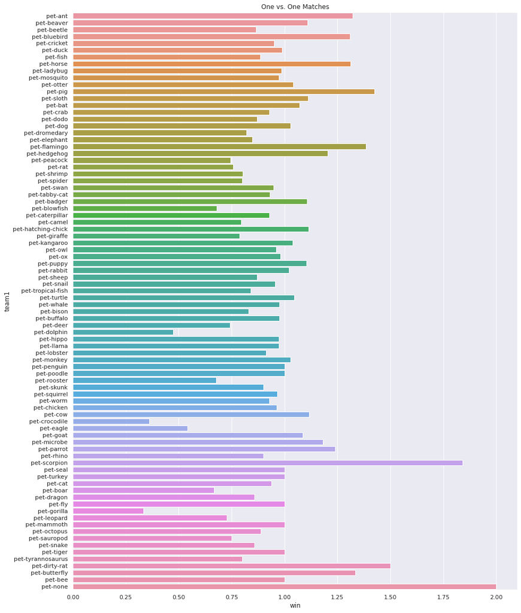

```python
sns.set(rc = {'figure.figsize':(15,20)})

fig, ax = plt.subplots()
plt.title("One vs. One Matches")
fig = sns.barplot(y=one["team1"], x=one["win"], ci=None)
```

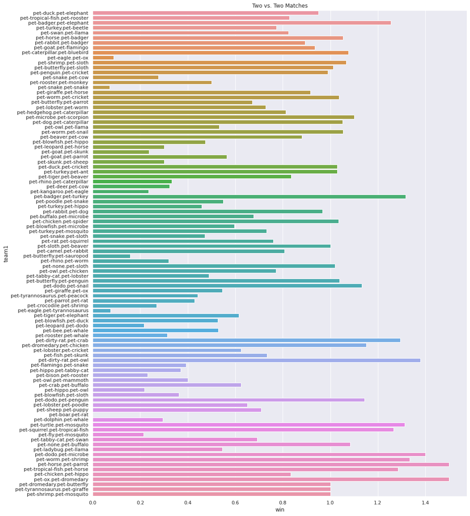

```python
sns.set(rc = {'figure.figsize':(15,20)})

fig, ax = plt.subplots()
plt.title("Two vs. Two Matches")
fig = sns.barplot(y=two["team1"], x=two["win"], ci=None)
```

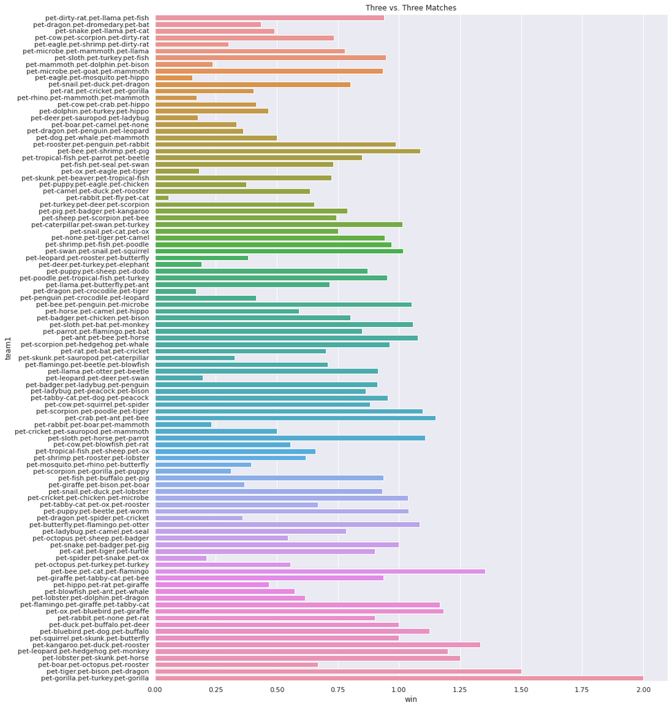

```python
sns.set(rc = {'figure.figsize':(15,20)})

fig, ax = plt.subplots()
plt.title("Three vs. Three Matches")
fig = sns.barplot(y=three["team1"], x=three["win"], ci=None)
```

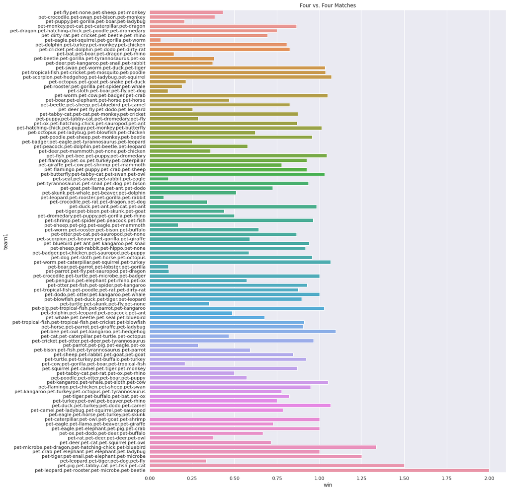

```python
sns.set(rc = {'figure.figsize':(15,20)})

fig, ax = plt.subplots()
plt.title("Four vs. Four Matches")
fig = sns.barplot(y=four["team1"], x=four["win"], ci=None)
```

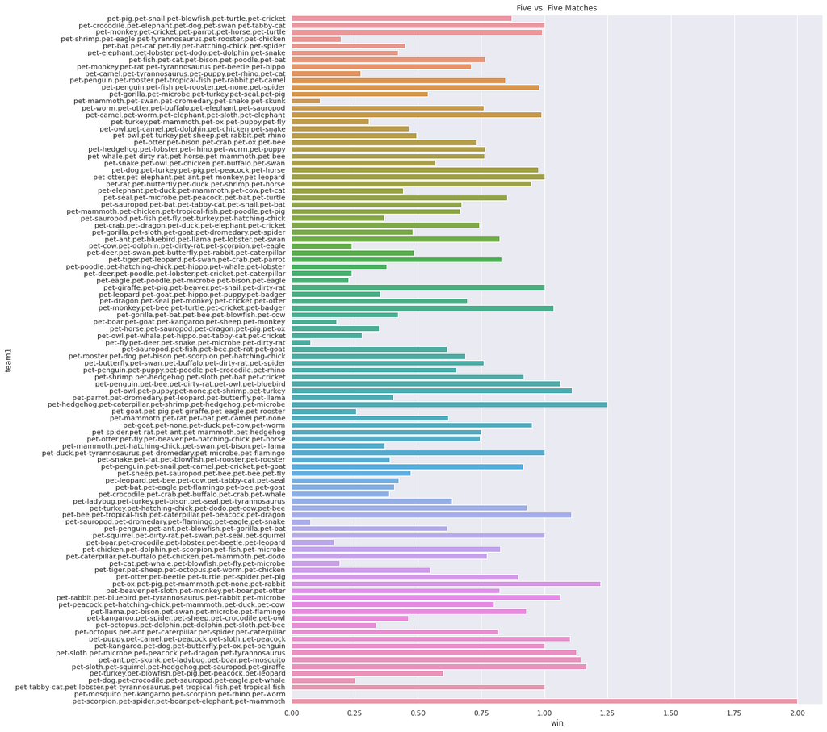

```python
sns.set(rc = {'figure.figsize':(15,20)})

fig, ax = plt.subplots()
plt.title("Five vs. Five Matches")
fig = sns.barplot(y=five["team1"], x=five["win"], ci=None)
```

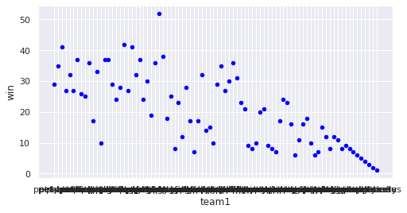

```python
sns.set(rc = {'figure.figsize':(8,4)})
one_wins.plot.scatter(x = "team1", y = "win", color = "blue")
```

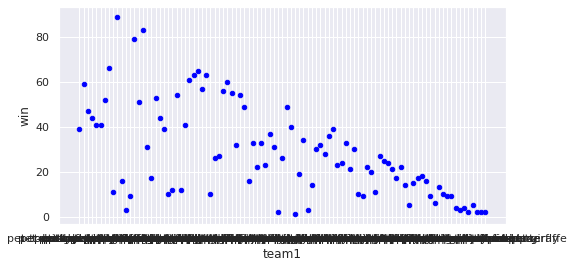

```python
sns.set(rc = {'figure.figsize':(8,4)})
two_wins.plot.scatter(x = "team1", y = "win", color = "blue")
```

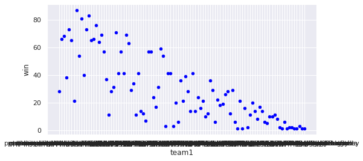

```python
sns.set(rc = {'figure.figsize':(8,4)})
three_wins.plot.scatter(x = "team1", y = "win", color = "blue")
```

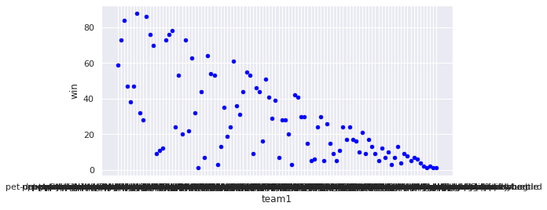

```python
sns.set(rc = {'figure.figsize':(8,4)})
four_wins.plot.scatter(x = "team1", y = "win", color = "blue")
```

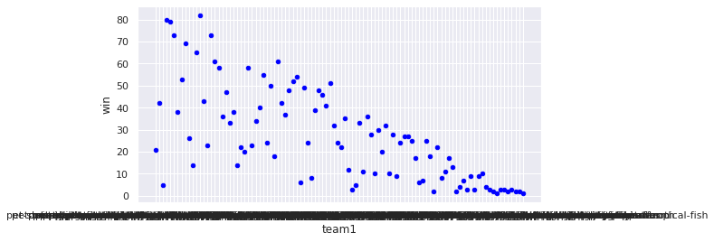

```python
sns.set(rc = {'figure.figsize':(8,4)})
five_wins.plot.scatter(x = "team1", y = "win", color = "blue")
```

### 4. Analysis

```python
max_value = one_wins.max()
print(max_value)

max_value = two_wins.max()
print(max_value)

max_value = three_wins.max()
print(max_value)

max_value = four_wins.max()
print(max_value)

max_value = five_wins.max()
print(max_value)
```

```
team1    pet-worm
win            52
dtype: object
team1    pet-worm.pet-snail
win                      89
dtype: object
team1    pet-turkey.pet-deer.pet-scorpion
win                                    87
dtype: object
team1    pet-worm.pet-rooster.pet-bison.pet-buffalo
win                                              88
dtype: object
team1    pet-worm.pet-otter.pet-buffalo.pet-elephant.pe...
win                                                     82
dtype: object
```

```python
test_teams = gen_team(1000, 5)
win = 0
loss = 0
best_team = ["pet-worm","pet-otter","pet-buffalo","pet-elephant", "pet-scorpion"]

for op in test_teams:
  try:
    res = Battle(Team(best_team), Team(op)).battle()
  except:
    pass
  # print(op, res)
  if res == 0:
    win +=1
  if res ==1:
    loss +=1
  if  res == 2:
    win+=1

print (win, loss)

win = 0
loss = 0
worst_team = ["pet-ant", "pet-badger", "pet-puppy", "pet-chicken", "pet-bluebird"]
for op in test_teams:
  try:
    res = Battle(Team(worst_team), Team(op)).battle()
  except:
    pass
  # print(op, res)
  if res == 0:
    win +=1
  if res ==1:
    loss +=1
  if  res == 2:
    win+=1
print(win,loss)
```

[output not shown]

This aligns with our before hypothesis, as we believed that teams with the highest tiers and rank would be the most successful.

## Conclusion

While we were thinking about this project, we were curious as to see if strategies that people have created in the community were optimal. We learned a lot about the game thanks to this project. Even though the game mechanics are simple, like chess, there can be tons of different strategies and ways to play the game.

Overall, the observations and conclusions we made were fairly surprising, as we have played SAP many many times and never would’ve known. Hopefully this tutorial will evolve the SAP community and improve strategies used by players, both experienced and inexperienced.

### Future Considerations

While we were not able to construct an absolutely optimal team for SAP, we were able to make some observations with regards to what pets are better than others. Even if we created an absolutely optimal team, it is often not possible to always construct the most optimal team due to the randomness of what pets are available to the player.

A next step that can be taken is a game AI using Deep Q Learning that can recommend the best pet to choose given whatever pets are available to the player during a certain round. However, one problem that would have to be dealt with is how to approach / quantify the randomness behind rerolling the shop and when rerolling is favorable for the player.